# Linear Mixed Models (LMMs) - Part 1

Joshua F. Wiley

2020-05-12

Download the raw `R` markdown code here https://jwiley.github.io/MonashHonoursStatistics/LMM1.rmd. These are the `R` packages we will use.

```r
options(digits = 4)

## new packages are lme4, lmerTest, and multilevelTools

library(data.table)
library(JWileymisc)
library(lme4)
library(lmerTest)
library(multilevelTools)
library(visreg)
library(ggplot2)
library(ggpubr)
library(haven)

## load data collection exercise data
## merged is a a merged long dataset of baseline and daily
dm <- as.data.table(read_sav("Merged.sav"))
```

# 1 Descriptive Statsitics on Multilevel Data

With multilevel data, basic descriptive statistics can be calculated in different ways. We will use the merged dataset from the daily collection exercise. This dataset merges the baseline and daily datasets in a single, long format file.

To start with, suppose we had such a merged file (generally, a convenient way to store and analyze multilevel data) and we wanted to calculate descriptive statistics on some between person variables, such as age and sex. We might start off as we have before using `egltable()` for some summary descriptive statistics.

```r
egltable(c("age", "female"), data = dm)
```

```
##                 M (SD)
## 1:    age 22.76 (2.96)
## 2: female  0.83 (0.38)
```

Note that as `female` is coded 0/1 and not a factor, by default we are given a mean and standard deviation. This is not so helpful. We could convert to a factor or set `strict=FALSE` in which case `egltable()` does not **strict**ly follow the class of each variable and instead if a variable only has a few unique values, assumes its categorical/discrete, regardless of its official class in `R`.

```r
egltable(c("age", "female"), data = dm, strict=FALSE)
```

```
##           M (SD)/N (%)
## 1:    age 22.76 (2.96)
## 2: female
## 3:      0    32 (17.5)
## 4:      1   151 (82.5)
```

Now we can see the mean and standard deviation for age and the frequencies and percentages of women and men in the study. However, this reveals a problem/error. There were not 32 men and 151 women in the study. What this actually is shown is the average age, weighted by the number of days of data available for each participant, and the total number of daily surveys completed by men and women. That happens because the between person variables are repeated in long format.

Let’s look at the data just for the first two participants in the following table. We can see that on all days, age and female scores are identical for IDs 1 and 2.

```r
knitr::kable(dm[ID %in% c(1, 2), .(ID, day, age, female)])
```

| ID | day | age | female |
| --- | --- | --- | --- |
| 1 | 1 | 29 | 1 |
| 1 | 5 | 29 | 1 |
| 2 | 1 | 37 | 0 |
| 2 | 2 | 37 | 0 |
| 2 | 3 | 37 | 0 |
| 2 | 4 | 37 | 0 |
| 2 | 5 | 37 | 0 |

This is how between person variables are typically stored when in a dataset combined with repeated measures data in long format. However, it renders descriptive statistics on them probably not what we really wanted. The means are essentially weighted means, participants who complete more days of data get a higher weighting because their ages are repeated more times. For categorical/discrete variables, what we get is the number of assessments / observations for each level of the categorical variable, in this case number of observations belonging to men and women. In this case, when using data tables, the solution is easy: drop duplicated rows and only keep one row of data per ID and then remake the table. The following code shows how to do this. The difference is in using `data = dm[!duplicated(ID)]` instead of `data = dm`.

```r
egltable(c("age", "female"), data = dm[!duplicated(ID)], strict=FALSE)
```

```
##           M (SD)/N (%)
## 1:    age 22.84 (3.18)
## 2: female
## 3:      0     8 (16.0)
## 4:      1    42 (84.0)
```

Yielding this nice descriptive statistics table:

```r
knitr::kable(egltable(c("age", "female"), data = dm[!duplicated(ID)], strict=FALSE))
```

|  | M (SD)/N (%) |
| --- | --- |
| age | 22.84 (3.18) |
| female |  |
| 0 | 8 (16.0) |
| 1 | 42 (84.0) |

When working with multilevel data and a mix of between variables (especially sociodemographics that are often asked once) and repeated measures variables, watch out for which are which type and select only one row per ID when calculating descriptives or graphs for between person variables. The same applies when making exploratory plots or figures.

This is wrong, has many duplicates for each age.

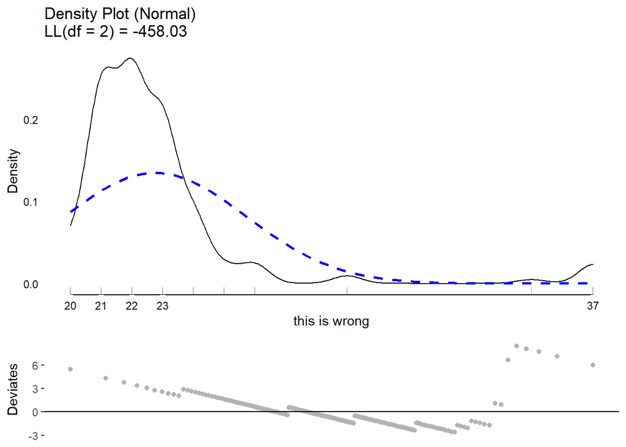

```r
plot(testDistribution(dm$age), varlab = "this is wrong")
```

This is right, only has one age per person.

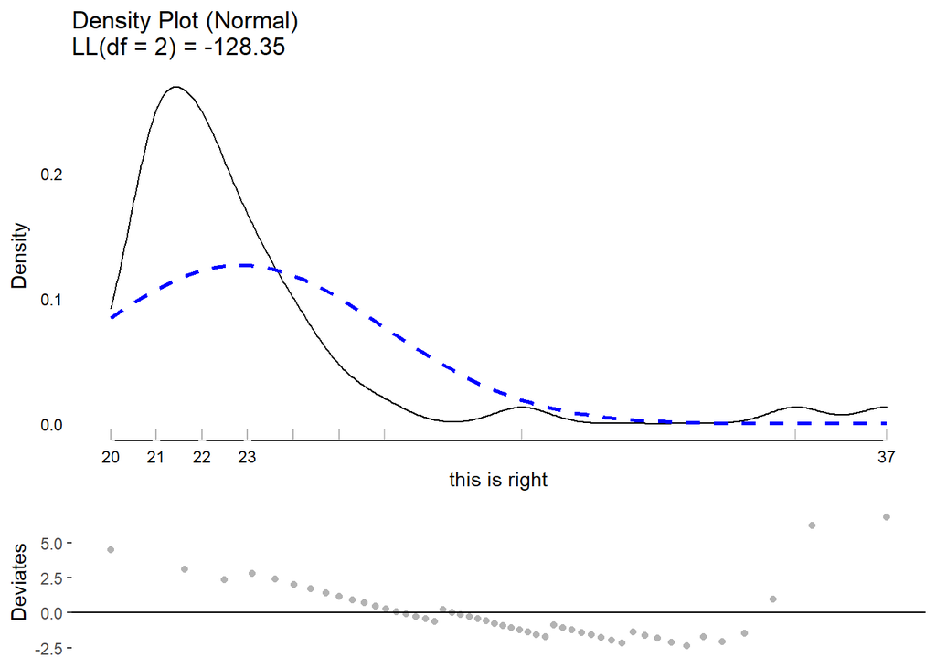

```r
plot(testDistribution(dm[!duplicated(ID)]$age), varlab = "this is right")
```

For repeated measures variables or any variable that can vary within a unit, we have several options for how to calculate descriptive statistics. The choices depend on whether the variable is continuous or categorical/discrete.

## 1.1 Continuous Variables

With multilevel data in long format, if we calculate the mean and variance of a variable, that would average across units and observations within units for the mean. The variance will incorporate both differences between units and variance within units (how much the data points vary around each unit’s own mean). That is, it is essentially the total variance.

Conversely, if we first average observations within a unit (e.g., person), then the mean will be the average of the individual averages, and the variance will only be the variability between individual units’ means. That is, we could first create a between person variable by averagine scores for each unit and then calculate descriptives as usual for that variable.

```r
dm[, c("Bstress", "Wstress") := meanDeviations(stress), by = ID]

egltable(c("Bstress"), data = dm[!duplicated(ID)])
```

```
##                 M (SD)
## 1: Bstress 3.77 (1.08)
```

We can interpret the descriptive statistics for `Bstress` as, “The mean and standard deviation of the average level of stress across days was 3.77 (SD = 1.08).”

For continuous variables, we also could calculate descriptives on all data points directly rather than on the average by person. Using all data points *can* unequally weight different participants (e.g., imagine one participant contributed 100 data points and 100 other participants each contributed 1 data point, the average wil be 50% the 100 participants with 1 data point and 50% from the 1 participant with 100 data points). The issue of weighting tends to be less important to the extent that clusters are all about the same size, and makes no difference if all clusters are identical (e.g., everyone has exactly 10 observations). If there are no systematic differences such that, for example, participants with the highest or lowest levels of stress tend to have more/fewer data points, then the mean is likely to be quite similar regardless of the approach.

The standard deviation from all data points is more like the total variance, combining variance from between and within participants. Thus, the standard deviation we expect to be at least the same and most likely larger than the standard deviation of the individual means, since those individual means “smooth” or remove variation within person.

```r
egltable(c("stress"), data = dm)
```

```
##                M (SD)
## 1: stress 3.82 (1.44)
```

In this example we can see that while the mean changes by .05, the standard deviation changes by quite a it more, reflecting the added within person variance.

A final approach that can be taken for continuous variables is to only pick a single observation from each unit to use in calculations. This tends to work best with longitudinal data where, for example, you could pick either the first day or the last day and calculate descriptives just for that one day as an example. To do this, we use the overall variable, but we subset the dataset to only include one day.

```r
egltable(c("stress"), data = dm[day == 1])
```

```
##                M (SD)
## 1: stress 3.90 (1.22)
```

This we can interpret as any other “usual” descriptive statistics. It is the average level of stress and standard deviation across participants, on the first day. If there are few time points (e.g., in a longitudinal study with just baseline, post, and follow-up), it might make sense to simply report the means and standard deviations of continuous variables at each time point. With a long dataset, this can easily be done by specifying the time point as the **g**rouping variable. **Note:** `egltable()` does not calculate correct tests, effect sizes, or p-values when the grouping variable is a repeated measures and not independent groups, so if you do it this way, ignore the tests and p-values, which assume independence.

```r
egltable(c("stress"), g = "day", data = dm)
```

```
##              1 M (SD)    2 M (SD)    3 M (SD)    4 M (SD)    5 M (SD)
## 1: stress 3.90 (1.22) 3.58 (1.53) 3.68 (1.27) 4.03 (1.53) 3.96 (1.80)
##                                              Test
## 1: F(4, 178) = 0.64, p = .633, Eta-squared = 0.01
```

If the data are already in wide format, one would simply calculate descriptive statistics on each of the separate variables representing each time point.

### 1.1.1 Summary

With multilevel, continuous variables, three approaches we discussed for calculating descriptive statistics are:

1. average by person and reprort descriptives on the individual averages;
2. report descriptives on the overall variable which captures the total variance but possibly unequally weights participants;
3. report descriptives on individual timepoints/assessments.

## 1.2 Categorical Variables

Compared to continuous variables, there are fewer options for presenting descriptive statistics with multilevel categorical data. For example, suppose people reported each day whether they: walked, rode a bike, or went to the gym for exercise. It does not make sense to average these data per person, although it could be possible to average, for example, the proportion of days each participant engaged in any one of those activities. However, categorical / discrete data are typically presented as frequencies and percentages. Averages of frequencies, especially with skewed data are not all that easy to interpret. For example, suppose that people either ride a bike or walk each day, using averages would appear to show that on average people walk half the days and ride a bike half the days.

The general choices, then for multilevel categorical data descriptives would either be to report descriptives for a variable overall or to report descriptives for a specific time point (e.g., day 1, 2, etc.) if longitudinal data.

```r
## overall
egltable("int_fr", data = dm, strict = FALSE)
```

```
##                N (%)
## 1: int_fr
## 2:      0  70 (38.3)
## 3:      1 113 (61.7)
```

```r
## one day
egltable("int_fr", data = dm[day==1], strict = FALSE)
```

```
##               N (%)
## 1: int_fr
## 2:      0 18 (35.3)
## 3:      1 33 (64.7)
```

These results show the total frequency and percentage of days that are 0 / 1 overall (first table) and the frequency and percentage of people that reported 0 / 1 on day 1 (second table).

## 1.3 Putting it All Together

Calculating and reporting descriptives statsitics from multilevel data stored in long format can require putting everything we talked about together. In this example, we want a descriptive statistics table for the following variables:

- female (measured baseline only; categorical)
- age (measured baseline only; continuous)
- selfesteem (measured baseline only; continuous)
- stress (measured daily; continuous, wanted average levels)
- int_fr (measured daily; categorical)

First for any continuous variables that we want to report on average levels only, `stress`, we create a between persion version. Then we subset the dataset to one row per person and calculate descriptives and store these in `desc1`. Then we calculate any descriptives we want on the daily data, here for `int_fr`. Then we name the columns the same using `setnames()` and finally we combine the two tables by binding them rowise, using `rbind()` and make a nice table with `kable()` from the `knitr` package.

```r
dm[, c("Bstress", "Wstress") := meanDeviations(stress), by = ID]

desc1 <- egltable(c("female", "age", "selfesteem", "Bstress"),
           data = dm[!duplicated(ID)], strict = FALSE)
desc2 <-   egltable(c("int_fr"), data = dm, strict = FALSE)
setnames(desc1, c("", "M (SD)/N (%)"))
setnames(desc2, c("", "M (SD)/N (%)"))

knitr::kable(rbind(desc1, desc2))
```

| V1 | M (SD)/N (%) |
| --- | --- |
| female |  |
| 0 | 8 (16.0) |
| 1 | 42 (84.0) |
| age | 22.84 (3.18) |
| selfesteem | 13.70 (3.22) |
| Bstress | 3.77 (1.08) |
| int_fr |  |
| 0 | 70 (38.3) |
| 1 | 113 (61.7) |

From these results we can see that 84% of the participants were women, the average age was 22.8y, the average of the mean across days stress was 3.77, and 61.7% of the days completed had `int_fr = 1`.

# 2 Linear Mixed Models

## 2.1 ML and REML

Two common estimators used with linear mixed mdoels are **M**aximum **L**ikelihood (ML) and **Re**stricted **M**aximum **L**ikelihood (REML). You can think of this somewhat the same as the formula for calculating a population’s variance versus estimating the population variance from a sample:

Also see: https://stats.stackexchange.com/questions/16008/what-does-unbiasedness-mean/16009#16009

$$\sigma^2_{pop} = \frac{\sum_{i=1}^{n} (X_i - \bar{X})^{2}}{n}$$

$$\sigma^2_{sample} = \frac{\sum_{i=1}^{n} (X_i - \bar{X})^{2}}{n - 1}$$

Generally speaking, REML, is less biased so we prefer it as an estimator and it is the usual default in LMMs. However, for some comparisons between models to be valid and some statistical tests to be valid, we need true maximum likelihood (ML) estimates so you will sometimes see the default REML option “turned off” to get pure ML estimates or a model be refit using ML instaed of REML. This is done in `R` using `REML = FALSE` to get ML.

## 2.2 Random Intercept Model

There are two main uses of intercept only models:

- To calculate the intraclass correlation coefficient (ICC)
- As a comparison to see how much better a more complex model fits.

To calculate the ICC, we use this equation:

$$ICC = \frac{\sigma^{2}_{intercept}}{\sigma^{2}_{intercept} +
\sigma^{2}_{residual}}$$

Following is an example of an intercept only model, where there is both a fixed effects intercept and a random intercept. The outcome variable is `stress`. All predictors come after the tilde, `~`. In this case, the only “predictors” are the fixed and random intercept, represented by `1`. The random intercept is random by `ID`. The function to fit linear mixed models is `lmer()` and comes from the `lme4` package. It also requires a dataset be specified, here `dm`. We can get a summary using `summary()`.

```r
## get rid of the haven_labelled class type for stress
dm[, stress := as.numeric(stress)]

ri.m <- lmer(stress ~ 1 + (1 | ID),
            data = dm,
            REML = TRUE)

summary(ri.m)
```

```
## Linear mixed model fit by REML. t-tests use Satterthwaite's method [
## lmerModLmerTest]
## Formula: stress ~ 1 + (1 | ID)
##    Data: dm
##
## REML criterion at convergence: 614
##
## Scaled residuals:
##    Min     1Q Median     3Q    Max
## -2.335 -0.577 -0.019  0.618  3.206
##
## Random effects:
##  Groups   Name        Variance Std.Dev.
##  ID       (Intercept) 0.84     0.917
##  Residual             1.20     1.096
## Number of obs: 183, groups:  ID, 50
##
## Fixed effects:
##             Estimate Std. Error     df t value Pr(>|t|)
## (Intercept)    3.793      0.158 50.395    24.1   <2e-16 ***
## ---
## Signif. codes:  0 '***' 0.001 '**' 0.01 '*' 0.05 '.' 0.1 ' ' 1
```

```r
iccMixed("stress", id = "ID", data = dm)
```

```
##         Var  Sigma    ICC
## 1:       ID 0.8404 0.4118
## 2: Residual 1.2006 0.5882
```

There are four main “blocks” of output from the summary.

1. A repetition of the model options, formula we used, and dataset used. This is for records so you know exactly what the model was. In *this* model, it shows use that we fit a LMM using restricted maximum likelihood (REML) and that the degrees of freedom were approximated using Satterthwaite’s method. The outcome variable is stress (`stress`) and there are only intercept predictors, `1`. The REML criterion at convergence is kind of like the log likelihood (LL), but unfortunately cannot be readily used to compare across models as easily as the actual LL (e.g., in AIC or BIC, which we’ll talk about more later).
2. Scaled Pearson residuals. These are raw residuals divided by the estimated standard deviation, so that they can be roughly interpretted as z-scores. The minimum and maximum are useful for identifying whether there are outliers present in the model residuals. In *this* model, we can see that the lowest residual is -2.3347 and the maximum residual is 3.2057 which are not too large. Absolute residuals of (e.g., 10) would be large enough that they are extremely unlikely by chance alone and likely represent outliers.
3. Random effects. These show a summary of the random effects in the model. Random effects are basically always also fixed effects, so the random effects only shows the standard deviation and variance of random effects, plus, if applicable, their correlations. The means are showon in the fixed effects section. In the case of a random intercept only model like this one, there are only two random effects: (1) the random intercept and (2) the random residual. We have both the standard deviation and variance of both. We will use the variances to calculate ICCs. In *this* model, the standard deviation of the random intercept, tells us that the average or typical difference between an individual’s average stress, and the population average stress is 0.9167. The standard deviation of the residuals tells us that the average or typical difference between an individual stress score and the predicted stress score is 1.0957. The random effects section also tells us how many observations and unique people/groups went into the analysis. In *this* model we can see that we had 50 people providing 183 unique observations.
4. Fixed effects. This section shows the fixed effects. It is a table, where each row is for a different effect / predictor and each column gives a different piece of information. The “Estimate” is the actual parameter estimate (i.e., THE fixed effect, the regression coefficient, etc.). The “Std. Error” is the standard error of the estimate, which captures uncertainty in the coefficient due to sampling variation. The “df” is the Satterthwaite estimated degrees of freedom. As an estimate, it may have decimals. The “t value” is the ratio of the coefficient to its standard error, that is: $t = \frac{Estimate}{StdError}$. The “Pr(>|t|)” is the p-value, the probability that by chance alone one would obtain as or a larger absolute t-value. The vertical bars indicate absolute values and the “Pr” stands for probability value. Note that `R` uses [scientific E notation](https://en.wikipedia.org/wiki/Scientific_notation). The number following the “e” indicates how many places to the right (if positive) or left (if negative) the decimal point should be moved. For example, 0.001 could be written 1e-3. 0.00052 could be written 5.2e-4. These often are used for p-values which may be numbers very close to zero. In *this* model, we can see that the fixed effect for the intercept is 3.7933 which is the like the mean of the random intercept and tells us the average level of stress, in this instance since there are no other predictors in the model.

Profile likelihood confidence intervals can be obtained using the `confint()` function. These confidence intervals capture the uncertainty in parameter estimates for both the fixed and random effects due to sampling variation. They do not capture indivdiual differences directly. Note that you only get confidence intervals for random effects when using the profile method, not when `method = "Wald"` although the Wald method is much faster. Profile likelihood confidence intervals are the default and are generally more accurate than Wald based confidence intervals, but also can be slower to calculate. Here both ways are shown.

```r
## Profile Confidence Intervals
ri.ci <- confint(ri.m, method = "profile", oldNames = FALSE)
```

```
## Computing profile confidence intervals ...
```

```r
ri.ci
```

```
##                    2.5 % 97.5 %
## sd_(Intercept)|ID 0.6774  1.194
## sigma             0.9779  1.238
## (Intercept)       3.4808  4.104
```

```r
## Wald Confidence Intervals
confint(ri.m, method = "Wald", oldNames = FALSE)
```

```
##                   2.5 % 97.5 %
## sd_(Intercept)|ID    NA     NA
## sigma                NA     NA
## (Intercept)       3.484  4.102
```

### 2.2.1 Diagnostics

Typical diagnostics and checks include checking for outliers, assessing whether the distributional assumptions are met, checking for homogeneity of variance and checking whether there is a linear association between predictors and outcome. With only an intercept, there is no need for checking whether a linear association is appropriate.

As for linear regressions, we can use `modelDiagnostics()` to calculate diagnostics and `plot()` to get a plot of the diagnostics.

The top left plot of the residuals helps check for outliers on the residuals. These plots show one relatively extreme value on the residuals. In this case, using the scaled pearson residuals, which are roughly like z scores, the size of the residual outliers are not too big as to likely be an issue (3.21 is not that large in z scores). The bottom left plot shows the distribution of the random intercept. No outliers are observed.

The density plots (and QQ deviates plot for residuals) indicate very mild non-normality, but it is not too extreme and close enough for inference.

Finally, on the top right, we check the homogeneity of variance. There is no clear trend in the residuals indicating that the homogeneity of variance assumption is reasonably met. The residuals show a characteristic banding when dealing with “continuous” variable that have a handful of possible values. This is not a problem per se, although if too extreme may indicate that treating the data as continuous is not a great.

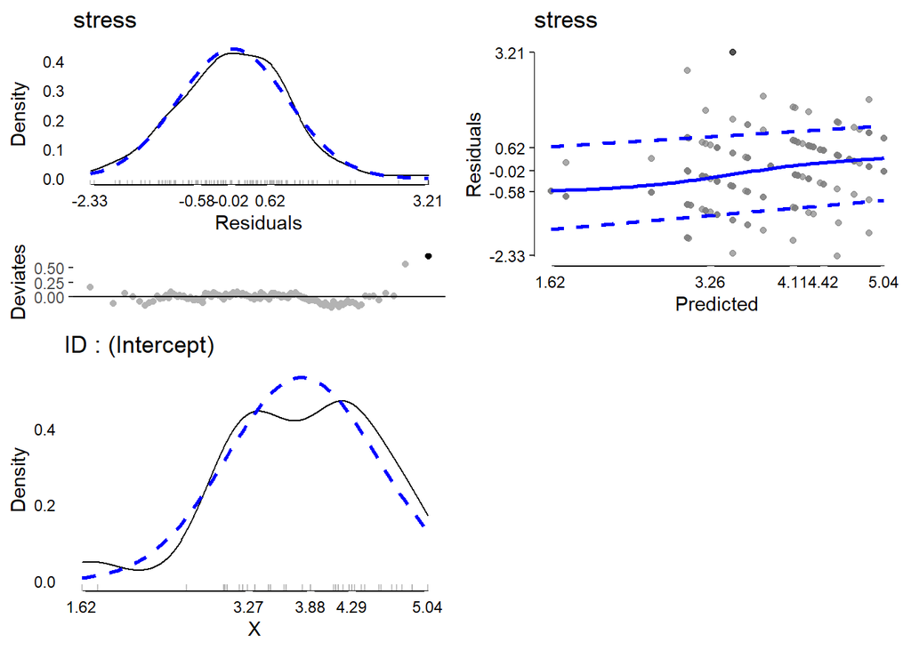

```r
plot(modelDiagnostics(ri.m), ncol = 2, nrow = 2, ask = FALSE)
```

With diagnostics reasonably met, we proceed with a write up.

### 2.2.2 Sample Write Up

An intercept only linear mixed model was fit to 183 stress scores from 50 people. The intraclass correlation coefficient was 0.4118 indicating that about 40% of the total variance in stress was between people and the other 60% is within person due to fluctuations across days. The fixed effect intercept revealed that the average [95% CI] stress was 3.7933 [3.48, 4.10]. However, there were individual differences, with the standard deviation for the random intercept being 0.9167 indicating that there are individual differences in the mean stress. Assuming the random intercepts follow a normal distribution, we expect most people to fall within one standard deviation of the mean, which in these data would be somewhere between: 2.8765, 4.71.

## 2.3 Random Intercept and Fixed Effects Models

Following is an example of a LMM with fixed effects and a random intercept (no random slopes). Although we did not explicitly add a fixed effects intercept by adding `1` to the equation, it is there by default. We still have a random intercept.

```r
fp.m <- lmer(stress ~ energy + (1 | ID),
            data = dm,
            REML = TRUE)

summary(fp.m)
```

```
## Linear mixed model fit by REML. t-tests use Satterthwaite's method [
## lmerModLmerTest]
## Formula: stress ~ energy + (1 | ID)
##    Data: dm
##
## REML criterion at convergence: 606.8
##
## Scaled residuals:
##    Min     1Q Median     3Q    Max
## -2.439 -0.583  0.050  0.573  3.363
##
## Random effects:
##  Groups   Name        Variance Std.Dev.
##  ID       (Intercept) 0.728    0.853
##  Residual             1.162    1.078
## Number of obs: 183, groups:  ID, 50
##
## Fixed effects:
##             Estimate Std. Error       df t value Pr(>|t|)
## (Intercept)   4.8368     0.3482 174.2219   13.89   <2e-16 ***
## energy       -0.2464     0.0744 178.6952   -3.31   0.0011 **
## ---
## Signif. codes:  0 '***' 0.001 '**' 0.01 '*' 0.05 '.' 0.1 ' ' 1
##
## Correlation of Fixed Effects:
##        (Intr)
## energy -0.904
```

There are four main “blocks” of output from the summary.

1. A repetition of the model options, formula we used, and dataset used. This is for records so you know exactly what the model was. In *this* model, it shows use that we fit a LMM using restricted maximum likelihood (REML) and that the degrees of freedom were approximated using Satterthwaite’s method. The outcome variable is stress (`stress`) and energy is a predictor. The REML criterion at convergence is kind of like the log likelihood (LL), but unfortunately cannot be readily used to compare across models as easily as the actual LL (e.g., in AIC or BIC).
2. Scaled Pearson residuals. These are raw residuals divided by the estimated standard deviation, so that they can be roughly interpretted as z-scores. The minimum and maximum are useful for identifying whether there are outliers present in the model residuals. In *this* model, we can see that the lowest residual is -2.4387 and the maximum residual is 3.3633 which while a bit large, are not so extreme if interpretted as z-scores as to be concerning. Absolute residuals of 10, for example, would be large enough that they are extremely unlikely by chance alone and likely represent outliers. We can see there are some more extreme positive than negative residuals. That means that predictions are sometimes too (extremely) low rather than too (extremely) high.
3. Random effects. These show a summary of the random effects in the model. Random effects are basically always also fixed effects, so the random effects only shows the standard deviation and variance of random effects, plus, if applicable, their correlations. The means are showon in the fixed effects section. In the case of a model where the only random effect is the intercept, the random effects show: (1) the random intercept and (2) the random residual. We have both the standard deviation and variance of both. In *this* model, the standard deviation of the random intercept, tells us that the average or typical difference between an individual’s estimated stress when energy is 0, and the population average estimated stress when energy is 0 is 0.8533. The standard deviation of the residuals tells us that the average or typical difference between an individual stress score and the predicted stress score is 1.0778. The random effects section also tells us how many observations and unique people/groups went into the analysis. In *this* model we can see that we had 50 people providing 183 unique observations.
4. Fixed effects. This section shows the fixed effects. It is a table, where each row is for a different effect / predictor and each column gives a different piece of information. The “Estimate” is the actual parameter estimate (i.e., THE fixed effect, the regression coefficient, etc.). The “Std. Error” is the standard error of the estimate, which captures uncertainty in the coefficient due to sampling variation. The “df” is the Satterthwaite estimated degrees of freedom. As an estimate, it may have decimals. The “t value” is the ratio of the coefficient to its standard error, that is: $t = \frac{Estimate}{StdError}$. The “Pr(>|t|)” is the p-value, the probability that by chance alone one would obtain as or a larger absolute t-value. The vertical bars indicate absolute values and the “Pr” stands for probability value. Note that `R` uses [scientific E notation](https://en.wikipedia.org/wiki/Scientific_notation). The number following the “e” indicates how many places to the right (if positive) or left (if negative) the decimal point should be moved. For example, 0.001 could be written 1e-3. 0.00052 could be written 5.2e-4. These often are used for p-values which may be numbers very close to zero. In *this* model, we can see that the fixed effect for the intercept is 4.8368 which is like the mean of the random intercept and tells us the average estimated stress score when energy = 0. The fixed effect (regression coefficient) for energy is -0.2464 which tells us how much on average (fixed effect) lower stress is expected to be when energy is one unit higher.

Profile likelihood confidence intervals can be obtained using the `confint()` function. These confidence intervals capture the uncertainty in parameter estimates for both the fixed and random effects due to sampling variation. They do not capture indivdiual differences directly. Note that you only get confidence intervals for random effects when using the profile method, not when `method = "Wald"` although the Wald method is much faster.

```r
fp.ci <- confint(fp.m, method = "profile", oldNames = FALSE)
```

```
## Computing profile confidence intervals ...
```

```r
fp.ci
```

```
##                     2.5 %  97.5 %
## sd_(Intercept)|ID  0.6162  1.1194
## sigma              0.9588  1.2149
## (Intercept)        4.1512  5.5265
## energy            -0.3944 -0.1004
```

### 2.3.1 Diagnostics and Checks

Typical diagnostics and checks include checking for outliers, assessing whether the distributional assumptions are met, checking for homogeneity of variance and checking whether there is a linear association between predictors and outcome.

Results look about the same as for the intercept only model, although two relatively extreme residuals are now identified. Still, interpretted as z scores, they are not bad enough to worry much about.

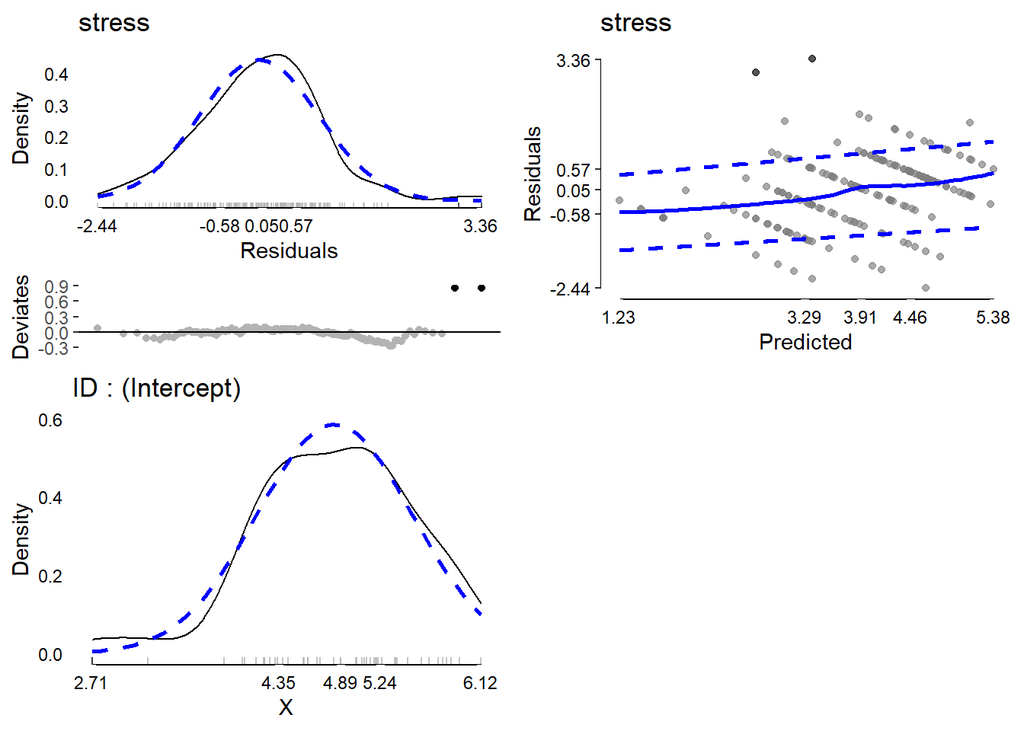

```r
plot(modelDiagnostics(fp.m),
     ncol = 2, nrow = 2, ask = FALSE)
```

### 2.3.2 Sample Write Up

To examine the association of stress and energy, a linear mixed model was fit. The final model included 183 stress scores from 50 people.  
The fixed effect intercept revealed that the average [95% CI] stress when energy is 0 was 4.8368 [4.15, 5.53]. However, there were individual differences, with the standard deviation for the random intercept being 0.8533 indicating that there are individual differences in the mean stress. Assuming the random intercepts follow a normal distribution, we expect most people to fall within one standard deviation of the mean, which in these data would be somewhere between: 3.9835, 5.6901. Using Satterthwaite’s approximation for degrees of freedom revealed that energy was statistically significantly associated with stress (p = .001). On average across people, a one unit higher energy score was associated with -0.2464 lower stress scores.

## 2.4 Between and Within Effects

When we have a time-varying predictor variable, we can separate it into a between and within portion and both of these new variables can be included in a LMM as predictors. After creating a between and within version of energy, `Benergy` and `Wenergy` we just enter both as fixed effects predictors.

```r
dm[, c("Benergy", "Wenergy") := meanDeviations(energy), by = ID]

fp.m2 <- lmer(stress ~ Benergy + Wenergy + (1 | ID),
              data = dm)

summary(fp.m2)
```

```
## Linear mixed model fit by REML. t-tests use Satterthwaite's method [
## lmerModLmerTest]
## Formula: stress ~ Benergy + Wenergy + (1 | ID)
##    Data: dm
##
## REML criterion at convergence: 607.1
##
## Scaled residuals:
##    Min     1Q Median     3Q    Max
## -2.459 -0.551  0.050  0.587  3.355
##
## Random effects:
##  Groups   Name        Variance Std.Dev.
##  ID       (Intercept) 0.713    0.844
##  Residual             1.165    1.079
## Number of obs: 183, groups:  ID, 50
##
## Fixed effects:
##             Estimate Std. Error       df t value Pr(>|t|)
## (Intercept)   5.5276     0.7059  48.0836    7.83  3.9e-10 ***
## Benergy      -0.4095     0.1631  47.5032   -2.51    0.015 *
## Wenergy      -0.2044     0.0835 136.3965   -2.45    0.016 *
## ---
## Signif. codes:  0 '***' 0.001 '**' 0.01 '*' 0.05 '.' 0.1 ' ' 1
##
## Correlation of Fixed Effects:
##         (Intr) Benrgy
## Benergy -0.978
## Wenergy  0.000  0.000
```

Profile likelihood confidence intervals can be obtained using the `confint()` function. These confidence intervals capture the uncertainty in parameter estimates for both the fixed and random effects due to sampling variation. They do not capture indivdiual differences directly. Note that you only get confidence intervals for random effects when using the profile method, not when `method = "Wald"` although the Wald method is much faster.

```r
fp.ci2 <- confint(fp.m2, method = "profile", oldNames = FALSE)
```

```
## Computing profile confidence intervals ...
```

```r
fp.ci2
```

```
##                     2.5 %   97.5 %
## sd_(Intercept)|ID  0.5988  1.09823
## sigma              0.9594  1.21549
## (Intercept)        4.1360  6.90401
## Benergy           -0.7277 -0.08818
## Wenergy           -0.3686 -0.04020
```

### 2.4.1 Diagnostics and Checks

Typical diagnostics and checks include checking for outliers, assessing whether the distributional assumptions are met, checking for homogeneity of variance and checking whether there is a linear association between predictors and outcome.

Results look about the same as for the intercept only model, although two relatively extreme residuals are now identified and the random intercept appears to be closer to a normal distribution now. Still, interpretted as z scores, the residuals are not bad enough to worry much about. Homogeneity of variance still appears approximately met.

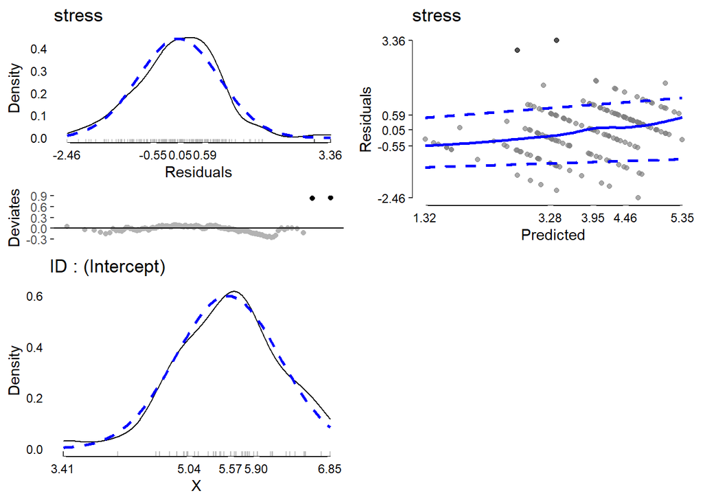

```r
plot(modelDiagnostics(fp.m2),
     ncol = 2, nrow = 2, ask = FALSE)
```

### 2.4.2 Sample Write Up

To examine the association of stress and energy, a linear mixed model was fit. To understand the association of energy and stress at both the between person and within person level, daily energy ratings were separated into average energy across the five days of the study (between energy) and daily deviations of energy from individuals’ own mean energy level (within energy). The final model included 183 stress scores from 50 people.  
The fixed effect intercept revealed that the average [95% CI] stress when between and within energy are 0 was 5.5276 [4.14, 6.90]. However, there were individual differences, with the standard deviation for the random intercept being 0.8444 indicating that there are individual differences in the mean stress. Assuming the random intercepts follow a normal distribution, we expect most people to fall within one standard deviation of the mean, which in these data would be somewhere between: 4.6833, 6.372. Using Satterthwaite’s approximation for degrees of freedom revealed that both between and within person energy were statistically significantly associated with stress (both p < .05). On average across people, at the between person level, a one unit higher average energy score was associated with -0.4095 lower stress scores. On average across people, at the within person level, a one unit higher than average daily energy score was associated with -0.2044 lower stress scores that day. The magnitude suggests that a one unit higher average energy level has about twice the magnitude of association with average stress as does a one unit higher daily energy level.

## 2.5 Statistical Inference

There is ambiguity in terms of how best to calculate degrees of freedom (df) for LMMs. By default `R` does not calculate the df and so does not provide p-values for the regression coefficients (fixed effects) from LMMs.

One easy, albeit imperfect, solution is to use the `lmerTest` package. `lmerTest` use Satterthwaite’s method to calculate approximate degrees of freedom and use these for the t-tests and p-values for each regression coefficient. To use `lmerTest` simply make sure that **both** `lme4` and `lmerTest` packages are installed and that you load the `lmerTest` package after `lme4`, by using: `library(lmerTest)`. This is shown in the examples above. Once that is done, all regular calls to `lmer()` function used to fit LMMs will automatically have df estimated and p-values.

Although this is a relatively common approach, it is not without limitations or debate. Other approaches include:

- assuming the sample size is large enough that the degrees of freedom are large enough that we can assume the parameters follow a normal distribution instead of a t-distribution.
- Relying on things like profile-based confidence intervals
- Bootstrapping, which is time intensive but probably the most robust of these options.

Here is a short example bootstrapping. Here we bootstrap the 95% confidence intervals, and if the interval does not include 0, we can conclude that $p < .05$, it is statistically significant. Although bootstrapping is robust, we often do not use it as it can be qutie time intensive for more complex models, especially those with more random effects.

```r
confint(fp.m, method = "boot")
```

```
## Computing bootstrap confidence intervals ...
```

```
##               2.5 %  97.5 %
## .sig01       0.5613  1.0991
## .sigma       0.9554  1.2156
## (Intercept)  4.1520  5.5182
## energy      -0.3974 -0.0922
```

# 3 You Try It

Fit an intercept only linear mixed model by completing the code below. Use the variable `energy` as your outcome variable. Calculate a summary of the model, model diagnostics, and find the intraclass correlation coefficient for `energy`. Then try fitting a linear model to energy (i.e., not a LMM, ignore the repeated measures). Look at the confidence intervals for the intercept from the LMM and the LM. Which one is wider / smaller?

```r
## store the model results in an object called "m2lmm"
m2lmm <- lmer()
```

```
## Error in checkFormulaData(formula, data, checkLHS = control$check.formula.LHS == : argument "formula" is missing, with no default
```

```r
## now make a summary of the model results



## what is the intraclass correlation coefficient for this variable?


## look at model diagnostics here



## try fitting an intercept only linear regression (not LMM)
## to energy
m2lr <- lm( )
```

```
## Error in terms.formula(formula, data = data): argument is not a valid model
```

```r
## calculate the confidence intervals from the LMM and the lm
```

# 4 Summary

## 4.1 Conceptual

Key points to take away conceptually are:

- How to calculate and interpret descriptive statistics for continuous and categorical variables from multilevel data, including different options presented in this topic
- How to interpret the random intercept in LMMs
- How to interpret fixed effects in LMMs
- How to create and interpret between and within effect predictors in LMMs
- Approaches to statistical inference in LMMs
- Basic assumptions and diagnostics for LMMs
- What types of confidence intervals can be calculated for fixed and/or random effects from LMMs
- What ML and REML mean and a simple understanding of when to use each

## 4.2 Code

| Function | What it does |
| --- | --- |
| `lmer()` | Fit a linear mixed model |
| `confint()` | Calculate confidence intervals from a LMM, defaults to profile likelihood confidence intervals |
| `summary()` | Get a summary table of the residuals, random effects, and fixed effects from a LMM |
| `modelDiagnostics()` | Calculate model diagnostics (outliers, normality, homogeneity) on a LMM |
| `iccMixed()` | Calculate the ICC for a variable from a random intercept only LMM |

# 5 Extra (Optional) - Likelihoods

**Note: if you just want to know what you need to know, you do not need to read this section..** If you want some more background that is beyond what you’re expected to know but may help provide some basis for a deeper understanding of ML and some later concepts, read on.

To understand ML, we need to understand what a likelihood is. A likelihood is not a probability. One way to think about this is that probabilities are related to results, whereas likelihoods are related to hypotheses. A very generic likelihood function looks like this:

$$\mathcal{L}(x | \theta)$$

where

- $x$ is some data (could be a vector or a whole dataset)
- $\theta$ is one or more parameter(s)

Often, we work with log likelihoods, $\mathcal{LL}$, rather than likelihoods directly because likelihoods tend to be multiplicative, but on the log scale, we can simply sum them up. The log likelihood will be equal to the (typically natural) log of the likelihood so we can mostly interpret them the same ways anyway as we use likelihoods as relative values, not absolute values.

Here is a simple example to help conceptually follow some of the basics. Here we define a log likelihood for the mean, $\mu$ as:

$$\mathcal{LL}(x | \mu) = -\sum_{i=1}^{n}(x_i - \mu)^{2}$$

We can create this function in `R` like this:

```r
LL <- function(x, mu) {
  -sum((x - mu)^2)
}
```

Now we can use our function in `R` to easily calculate our log likelihood for the data for different values of $\mu$. For example, let’s work with the `mpg` variable from `mtcars`. Here is a graph.

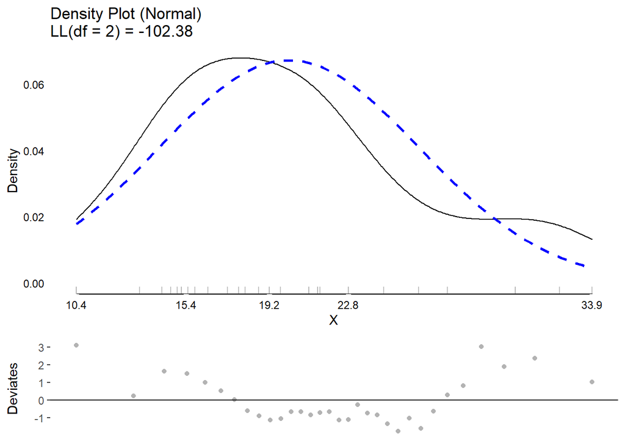

```r
plot(testDistribution(mtcars$mpg))
```

We can ask, what is the log likelihood of the data given, $\mu = 10$?

```r
LL(mtcars$mpg, mu = 10)
```

```
## [1] -4384
```

What about if $\mu = 15$?

```r
LL(mtcars$mpg, mu = 15)
```

```
## [1] -1955
```

Remember, LLs are basically always used in a relative fashion. So what can we say? Well, the LL is higher for $\mu = 15$ than it is for $\mu = 10$. That does not tell us that the mean, $\mu$ **IS** 15. That is, we do not answer is our hypothesis “true”. However, we can say that the data are more likely to come from a distribution where $\mu = 15$ than they are to come from a distribution where $\mu = 10$.

We would say that $\mu = 15$ has higher likelihood than does $\mu = 10$, for these data. Generally, we don’t just want to find *higher* (log) likelihoods. It would be nice to find the **maximum** likelihood estimates. What value of $\mu$ would give us the highest possible, the maximum (log) likelihood value? Simplistically, we could think of trying lots and lots of different values of $\mu$ and comparing all of them to find the highest. We could plot this, which would look as follows.

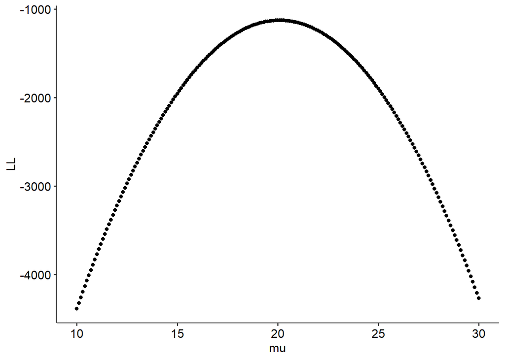

```r
tests <- data.table(
  mu = seq(from = 10, to = 30, by = .1))

tests[, LL := LL(mtcars$mpg, mu = mu), by = mu]

ggplot(tests, aes(mu, LL)) +
  geom_point() +
  theme_pubr()
```

Obviously this is not all possible values of $\mu$, but for $\mu$ values between 10 and 30 in increments of 0.1, we can see that the LL peaks at about 20. If we order our dataset so that the highest LL estimates are at the top, we will see that the maximum LL estimate of $\mu$ **of those we tried** was 20.1. This matches the arithmetic mean of `mpg`, within decimals.

```r
tests[order(-LL)]
```

```
##        mu    LL
##   1: 20.1 -1126
##   2: 20.0 -1126
##   3: 20.2 -1126
##   4: 19.9 -1127
##   5: 20.3 -1127
##  ---
## 197: 29.9 -4205
## 198: 10.2 -4256
## 199: 30.0 -4268
## 200: 10.1 -4320
## 201: 10.0 -4384
```

```r
mean(mtcars$mpg)
```

```
## [1] 20.09
```

What we have just done is a very simple form of an algorithm to try to find the maximum likelihood estimate of the mean. In practice, maximum likelihood estimation typically:

1. Has a more complex likelihood function
2. Rather than simply try lots of values, special algorithms iterate to try to purposefully move from a starting point to higher likelihood values. This is what hapens, for example with GLMs and in LMMs. Possible values of the parameters are tried, their likelihood evaluated, new parameter values tried, and the algorithm stops iterating in cycles once it cannot find any parameter values that will further increase the likelihood. The maximum likelihood estimates have been found.

In some cases, rather than needing to try different parameter values, we can do maths to figure out an equation to directly calculate the maximum likelihood values. For example, it can be proven that the equation for the arithmetic mean **is** the maximum likelihood estimate of the mean of some data. No need to iterate.

Beyond understanding how (log) likelihoods contribute to finding maximum likelihood estimates, the other useful take away point from this is that just as we compared the likelihood of two different possible $\mu$ values to find out that $\mu = 15$ generated a higher likelihood than did $\mu = 10$, down the track you’ll see that we can compare different models using their LLs or variations of the LL to try to decide between two competing models.

For complex models, including LMMs, the LLs also can be used to calculate boundaries on parameters. For example, the likelihoods can be profiled to find the 95% confidence intervals for a parameter. This is slower but sometimes more robust approach. The idea is basically to hold other parameters constant and vary one parameter and see how much the likelihood of the overall model changes and use that define the lower limit and upper limit of the confidence interval.

Compared to maximum likelihood estimates, REML estimates do not generate true (log) likelihood values and so cannot be used in quite the same way for comparing different models, that may rely on a true likelihood. However, if you are just estimating one model, the REML estimates are actually less biased estimates than the ML estimates so are a good default.

If you want to read more in this area, see these links.

https://towardsdatascience.com/a-gentle-introduction-to-maximum-likelihood-estimation-9fbff27ea12f and https://towardsdatascience.com/maximum-likelihood-estimation-explained-normal-distribution-6207b322e47f

**This is the end of the side diversion about likelihoods. Again you do not need to understand this section, it is here only for those interested in going a bit deeper and having more ways to think about ML and what is really meant by a likelihood.**